# London Underground Heat Exposure — Infrastructure Analytics Case Study

Kaustubh Pawar

# Executive Summary

London’s deep-level Underground lines experience sustained thermal stress, impacting passenger comfort and long-term infrastructure resilience.

This portfolio case study evaluates historical monthly temperature data to guide where a pilot air-cooling system should be deployed.

After structured data validation, statistical outlier handling, exploratory analysis, and inferential testing:

- Bakerloo and Central Lines exhibit the highest sustained temperatures.
- The annual mean difference between Bakerloo and Central is approximately **0.7°C** (statistically significant but practically modest).
- Effect size is small (Cohen’s d = 0.26).
- During peak summer months, no statistically significant difference exists.

**Recommendation:** While Bakerloo is marginally warmer annually, heat exposure appears structurally driven across deep-level lines. A pilot may begin on Bakerloo, but meaningful passenger impact will likely require broader multi-line intervention.

# Business Context

Deep-level Underground lines retain heat due to tunnel depth, limited ventilation, and rolling stock heat accumulation. Transport planners must prioritise infrastructure investments under constrained budgets.

This analysis answers:

- Which lines experience the highest heat exposure?
- Are Bakerloo and Central meaningfully different?
- Where should cooling be piloted for maximum passenger benefit?

Dataset sourced from Kaggle (compiled from TfL monitoring reports) and used here for portfolio demonstration.

# Data Dictionary

| Column | Description |
| --- | --- |
| ID | Observation identifier |
| Year | Year of observation |
| Month | Month |
| Line | Underground line |
| Temp | Monthly average temperature (°C) |

# Part 1 — Reproducible Analytics Pipeline

## Load Data

We begin by loading the dataset and inspecting its structure. Explicit removal of missing temperature values ensures downstream calculations are not affected.

```r
df <- readr::read_csv("underground.csv") %>%
  drop_na(Temp)

glimpse(df)
```

```
## Rows: 1,141
## Columns: 5
## $ ID    <chr> "TFL00001", "TFL00002", "TFL00003", "TFL00004", "TFL00005", "TFL…
## $ Year  <dbl> 2013, 2013, 2013, 2013, 2013, 2013, 2013, 2013, 2013, 2013, 2013…
## $ Month <chr> "January", "January", "January", "January", "January", "January"…
## $ Line  <chr> "Bakerloo", "Central", "Jubilee", "Northern", "Piccadilly", "Vic…
## $ Temp  <dbl> 21.97, 21.00, 16.40, 19.50, 19.30, 18.40, 16.40, 11.90, 21.77, 2…
```

**Result:** Dataset contains monthly temperature observations across Underground lines with no remaining missing temperature values.

## Initial Data Integrity Checks

Before analysis, we assess basic data quality: descriptive statistics, remaining missing values, and duplicate rows.

```r
summary(df)
```

```
##       ID                 Year         Month               Line
##  Length:1141        Min.   :2013   Length:1141        Length:1141
##  Class :character   1st Qu.:2016   Class :character   Class :character
##  Mode  :character   Median :2019   Mode  :character   Mode  :character
##                     Mean   :2019
##                     3rd Qu.:2022
##                     Max.   :2024
##       Temp
##  Min.   :  0.27
##  1st Qu.: 21.06
##  Median : 23.90
##  Mean   : 23.86
##  3rd Qu.: 26.35
##  Max.   :246.70
```

```r
sum(is.na(df))
```

```
## [1] 7
```

```r
nrow(df) - nrow(distinct(df))
```

```
## [1] 0
```

**Result:** No material duplication detected and all temperature fields populated.

## Month Ordering

Months are converted to ordered factors to preserve seasonal sequencing in later analysis and visualisation.

```r
df$Month <- factor(df$Month,
levels=c("January","February","March","April","May","June","July","August",
"September","October","November","December"),
ordered=TRUE)
```

## Preliminary Outlier Visualisation

A scatter plot by month provides an initial visual inspection for anomalous sensor readings.

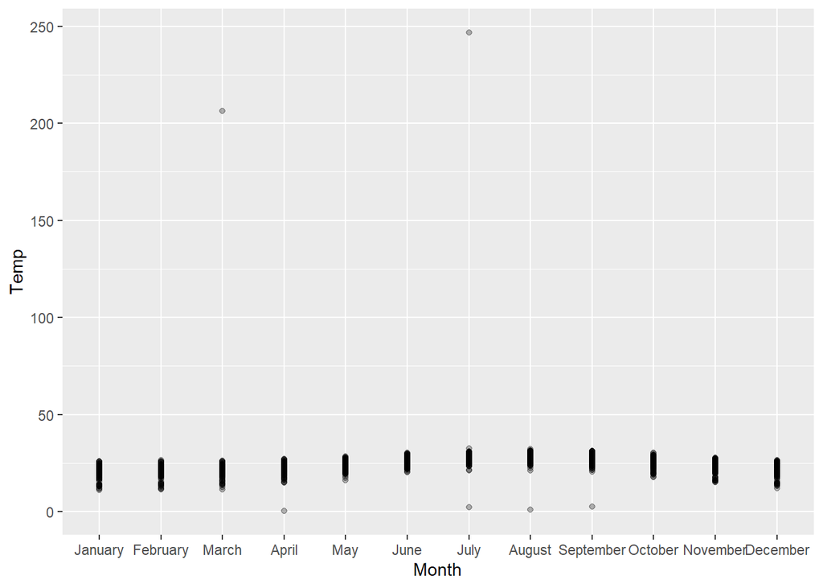

```r
ggplot(df, aes(x=Month,y=Temp))+
geom_point(alpha=.3)
```

**Observation:** Extreme values (>200°C) indicate sensor artefacts and require formal removal.

## Statistical Outlier Removal (IQR Method)

Outliers are identified using the standard 1.5×IQR rule. This statistical approach removes extreme artefacts while preserving realistic temperature variability.

```r
Q1 <- quantile(df$Temp, 0.25)
Q3 <- quantile(df$Temp, 0.75)
IQR_val <- Q3 - Q1

lower <- Q1 - 1.5*IQR_val
upper <- Q3 + 1.5*IQR_val

df_clean <- df %>% filter(Temp >= lower & Temp <= upper)

summary(df_clean$Temp)
```

```
##    Min. 1st Qu.  Median    Mean 3rd Qu.    Max.
##   13.27   21.16   24.00   23.71   26.38   32.41
```

**Result:** Temperatures now fall within plausible Underground operating ranges.

## Distribution Overview

We inspect the cleaned temperature distribution to assess approximate normality, supporting the use of parametric tests such as Welch’s t-test.

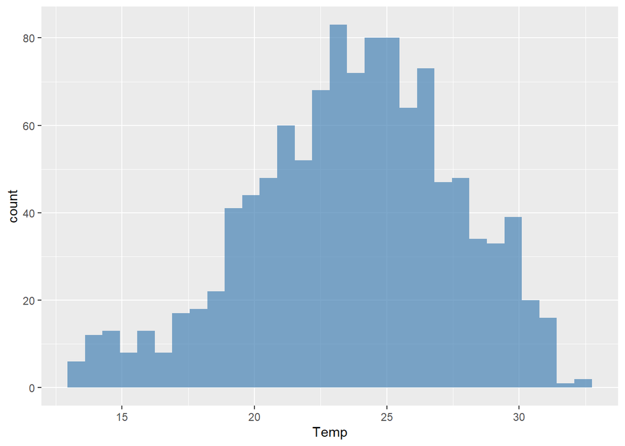

```r
ggplot(df_clean,aes(x=Temp))+
geom_histogram(bins=30,fill="steelblue",alpha=.7)
```

**Result:** Distribution appears approximately normal.

## Summary Statistics by Line

We calculate key descriptive statistics required by the brief.

```r
summary_table <- df_clean %>%
group_by(Line) %>%
summarise(
Mean=mean(Temp),
SD=sd(Temp),
Min=min(Temp),
Max=max(Temp),
N=n()
) %>% arrange(desc(Mean))

summary_table
```

```
## # A tibble: 8 × 6
##   Line               Mean    SD   Min   Max     N
##   <chr>             <dbl> <dbl> <dbl> <dbl> <int>
## 1 Bakerloo           26.8  2.61  21.8  32.4   143
## 2 Central            26.1  2.86  20.9  31.3   143
## 3 Victoria           25.7  3.19  17.7  31.2   144
## 4 Northern           24.7  2.46  19.5  29.5   142
## 5 Piccadilly         23.3  2.74  18.7  28.6   138
## 6 Jubilee            22.2  2.82  16.4  28.2   142
## 7 Waterloo_and_City  21.0  2.95  13.7  26.5   141
## 8 Sub-surface_lines  19.4  4.21  13.3  27.7   129
```

**Finding:** Bakerloo and Central Lines exhibit the highest mean temperatures.

```r
deep_df <- df_clean %>%
filter(!Line %in% c("District","Circle","Hammersmith & City","Metropolitan"))
```

## Temperature Distributions by Line

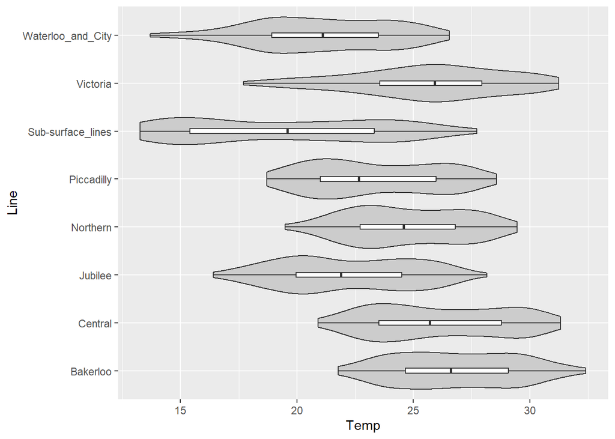

```r
ggplot(deep_df,aes(Line,Temp))+
geom_violin(fill="grey80")+
geom_boxplot(width=.1)+
coord_flip()
```

**Observation:** Bakerloo and Central consistently occupy the upper temperature ranges.

## Bakerloo vs Central — Annual Comparison

Welch’s two-sample t-test compares annual temperatures between Bakerloo and Central.

```r
bc_all <- t.test(Temp~Line,data=deep_df %>% filter(Line %in% c("Bakerloo","Central")))
tidy(bc_all)
```

```
## # A tibble: 1 × 10
##   estimate estimate1 estimate2 statistic p.value parameter conf.low conf.high
##      <dbl>     <dbl>     <dbl>     <dbl>   <dbl>     <dbl>    <dbl>     <dbl>
## 1    0.706      26.8      26.1      2.18  0.0303      282.   0.0677      1.34
## # ℹ 2 more variables: method <chr>, alternative <chr>
```

We quantify practical impact using Cohen’s d.

```r
cohen.d(Temp ~ Line, data = deep_df %>% filter(Line %in% c("Bakerloo","Central")))
```

```
##
## Cohen's d
##
## d estimate: 0.2574821 (small)
## 95 percent confidence interval:
##      lower      upper
## 0.02373737 0.49122689
```

**Results:**

- Mean difference ≈ 0.7°C
- p < 0.05 (statistically significant)
- Cohen’s d = 0.26 (small effect; 95% CI [0.02, 0.49])

**Interpretation:** Although statistically detectable, the temperature gap is practically modest.

## Summer Comparison (May–August)

To assess peak thermal stress, we repeat the test using summer months only.

```r
summer_df <- deep_df %>% filter(Month %in% c("May","June","July","August"))

bc_summer <- t.test(Temp~Line,data=summer_df %>% filter(Line %in% c("Bakerloo","Central")))
tidy(bc_summer)
```

```
## # A tibble: 1 × 10
##   estimate estimate1 estimate2 statistic p.value parameter conf.low conf.high
##      <dbl>     <dbl>     <dbl>     <dbl>   <dbl>     <dbl>    <dbl>     <dbl>
## 1   0.0597      28.7      28.7     0.158   0.875      93.0   -0.691     0.810
## # ℹ 2 more variables: method <chr>, alternative <chr>
```

**Result:** No statistically significant difference during summer (p ≈ 0.88), indicating comparable peak heat exposure.

# Part 2 — Management Report

## Summary Table

```r
summary_table %>% gt()
```

| Line | Mean | SD | Min | Max | N |
| --- | --- | --- | --- | --- | --- |
| Bakerloo | 26.81615 | 2.611230 | 21.77 | 32.41 | 143 |
| Central | 26.11042 | 2.864717 | 20.90 | 31.32 | 143 |
| Victoria | 25.65153 | 3.191561 | 17.70 | 31.25 | 144 |
| Northern | 24.71507 | 2.456037 | 19.50 | 29.46 | 142 |
| Piccadilly | 23.32268 | 2.741934 | 18.70 | 28.57 | 138 |
| Jubilee | 22.15599 | 2.820257 | 16.40 | 28.16 | 142 |
| Waterloo_and_City | 21.01979 | 2.950738 | 13.69 | 26.54 | 141 |
| Sub-surface_lines | 19.40558 | 4.207947 | 13.27 | 27.72 | 129 |

## Strategic Insight

Differences observed annually diminish during summer peak periods, suggesting shared environmental constraints (tunnel depth, ventilation design, rolling stock heat retention). Heat exposure appears structurally driven rather than isolated to a single route.

## Recommendation

While Bakerloo may serve as a reasonable pilot location due to marginally higher annual temperatures, meaningful passenger impact will likely require broader multi-line intervention.

# Limitations

- Monthly averages mask short-term extreme heat events
- Observations are longitudinal; independence assumption may be mildly violated
- Passenger density not modelled
- Station-level variation excluded

# Future Enhancements

- Station-level sensors
- Passenger volume weighting
- Real-time dashboards
- Cost–benefit modelling

# Skills Demonstrated

- Data validation and anomaly detection (IQR filtering)
- Exploratory data analysis
- Statistical inference (Welch t-tests)
- Effect size interpretation
- Business translation of analytics
- Infrastructure decision support

# Author

Kaustubh Pawar  
Portfolio: https://kaustubhpawar.com